# Time Complexity Isn’t All You Need

So here are two ways to sum the same array. The arithmetic is completely identical, and both of them are O(n²). And yet, on my laptop, one of them runs about 70 times slower than the other. Nothing about the algorithm itself changed at all. The only thing that’s actually different between them is the order the elements get read in.

Big-O is the tool your university course preaches for choosing between your data structures and algorithms, and the rule it gives you is dead simple: the much lower asymptotic cost always wins. And that general idea isn’t wrong, exactly, but it’s more so describing an idealised machine, a sort of perfect world where every memory access costs exactly the same and branches are basically free. In reality, no such machine actually exists. In real life, the way a CPU is physically built matters a whole lot, and sometimes it’s even the entire problem. Memory is laid out in layers, with little fast caches sitting right up against the core and the big slow main memory parked much further away, and on top of that the hardware spends a lot of its time just guessing what you’re going to do next. So those constant factors that Big-O so happily throws away are very often the things that actually end up deciding which option is faster at the sizes you’re realistically going to run in practice.

Anyway, I’ve got three little experiments for you below. Every single number here was measured on the one machine, and the code is all sitting up at github.com/tms-h/comssa-may so you can just run it yourself if you want. One warning before you do, though: make sure you compile with optimisations turned on. At `-O0` the numbers basically fall apart and none of this really holds.

## Experiment 1: same loop, two orders

Okay so take a 256 MB grid of ints and sum up every element. The two loops below both do exactly that, and honestly the only thing that changes between them is which index ends up sitting on the inner loop.

```cpp
// Version A: inner loop runs over j (the contiguous direction)
long long sum = 0;
for (int i = 0; i < N; ++i)
    for (int j = 0; j < N; ++j)
        sum += a[i * N + j];
```

```cpp
// Version B: inner loop runs over i (jumps N ints each step)
long long sum = 0;
for (int j = 0; j < N; ++j)
    for (int i = 0; i < N; ++i)
        sum += a[i * N + j];
```

Both of them touch every single element once, and both do the exact same additions along the way. So before you scroll on down: is there even a difference here at all? Reading across the rows or down the columns is surely the same amount of work either way, and this is all probably just going to be noise, right?

Well, here’s what actually happened.

| version | inner loop | time |
| --- | --- | --- |
| A (row-major) | `j` varies fastest | **5.06 ms** |
| B (column-major) | `i` varies fastest | **347.83 ms** |

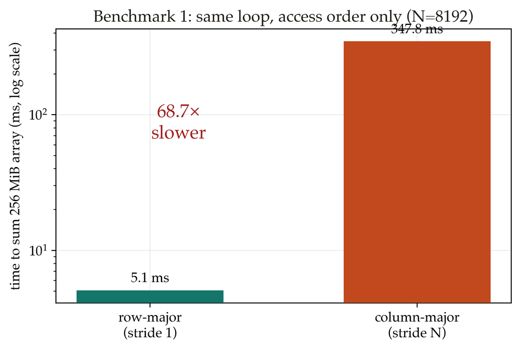

Bar chart on a log scale. Version A (row-major) takes about 5 ms and Version B (column-major) takes about 348 ms for the identical sum over a 256 MB array.

A took 5.06 ms. B took a whopping 347.83 ms, for the exact same sum. That’s about 70 times slower. And the reason really comes down to this: memory doesn’t just come back to you one int at a time. It actually arrives in 64-byte chunks called cache lines, which works out to roughly sixteen ints each. Version A reads straight along a row, so it ends up using all sixteen ints in a line before it ever has to move on, and the hardware notices that nice steady forward march and starts grabbing the next line early for you. Version B, on the other hand, reads down a column, so it uses a single int out of a line and then immediately jumps far enough away that the next read just misses the cache all over again. So almost every read in B ends up basically sitting there, twiddling its thumbs, waiting on main memory.

Same Big-O, both of them O(n²), and yet one is 70 times faster than the other. The thing doing all the actual work here is the exact thing school never quite gets around to mentioning.

## Experiment 2: when linear search wins

Right, here’s another one. Binary search halves a sorted array on each step and runs in O(log n), while a plain linear scan just checks the elements one at a time, so it’s O(n). And since log(n) < n for every n > 0, well, binary search should obviously win at every single size, right? To actually check that, I swept the array size N and ran a whole pile of random lookups against a sorted array, timing each method per query.

| N | linear (ns/query) | binary (ns/query) | winner |
| --- | --- | --- | --- |
| 8 | 4.54 | 6.02 | **linear** |
| 64 | 4.09 | 7.46 | **linear** |
| 128 | 7.38 | 8.92 | **linear** |
| 256 | 13.97 | 10.40 | binary |
| 1024 | 53.67 | 14.28 | binary |
| 65536 | 4028.54 | 42.10 | binary |

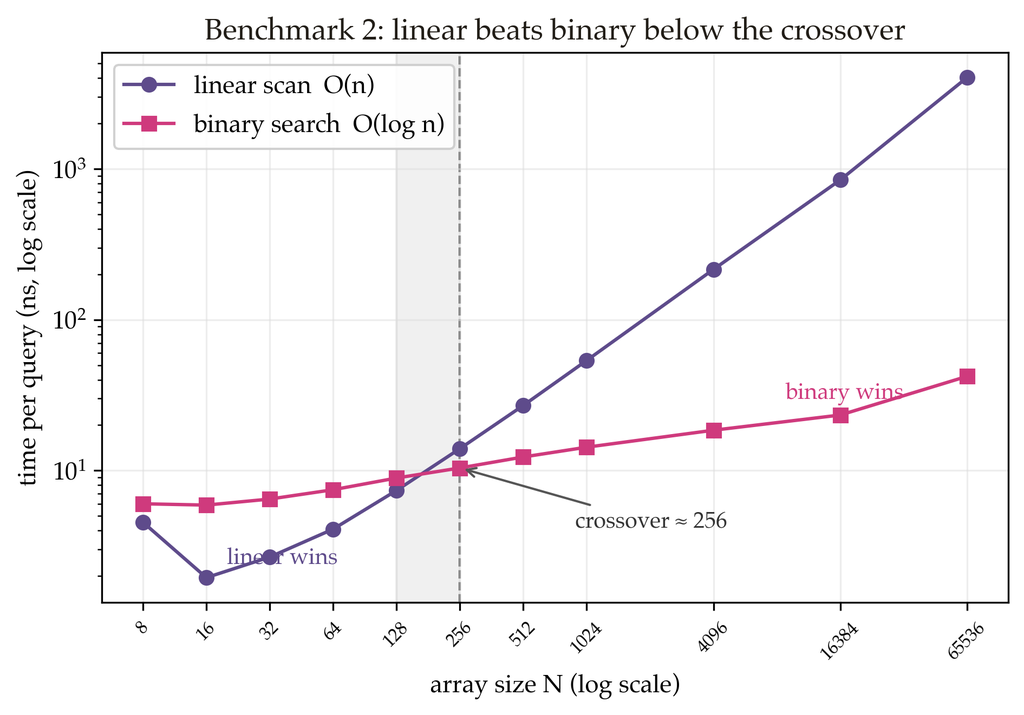

Log-log line chart of time per query against array size N. The linear-scan line is lower for small N, the two lines cross near N equals 256, and the linear line then rises far above binary search.

Well, huh, that’s a bit surprising. The linear scan is actually faster all the way up to about 128 elements, and 128 is honestly not a small array at all. Plenty of real lookups happen in arrays smaller than that, which means linear is quietly winning across most of the everyday cases you’re ever actually going to hit. The two methods only cross over somewhere around N = 256 here, and past that point binary search just runs away with it.

The reason is a pretty short one, actually. A small array sits entirely inside the fast cache, so the scan is really just one tight little loop that the CPU rips straight through. Binary search, on the other hand, jumps off to a spot that depends on the comparison it just made, so the branch predictor can’t really guess where it’s going to land, and the pipeline ends up stalling on basically every step. It’s only once the array gets properly large that those few clever jumps start actually beating the cost of scanning through thousands of elements.

## Experiment 3: the cost of finding the node

This is the one that surprised me the most, honestly. Deleting from a linked list is O(1) once you’re already holding the node, while deleting from an array is O(n), because everything sitting after it has to shift down to fill the gap. So run 20,000 deletes and the list does at most 20,000 nice cheap splices, while the vector might have to shift nearly 20,000 elements on every single delete. On paper, the vector is clearly doing orders of magnitude more work. But the catch the textbook example always quietly skips right over is that you actually have to find the element first before you can go and delete it. So the workload here walks from the front to find a value, erases it, and then just repeats until the whole container is empty.

| container | time |
| --- | --- |
| `std::vector` | **49.33 ms** |
| `std::list` | **242.14 ms** |

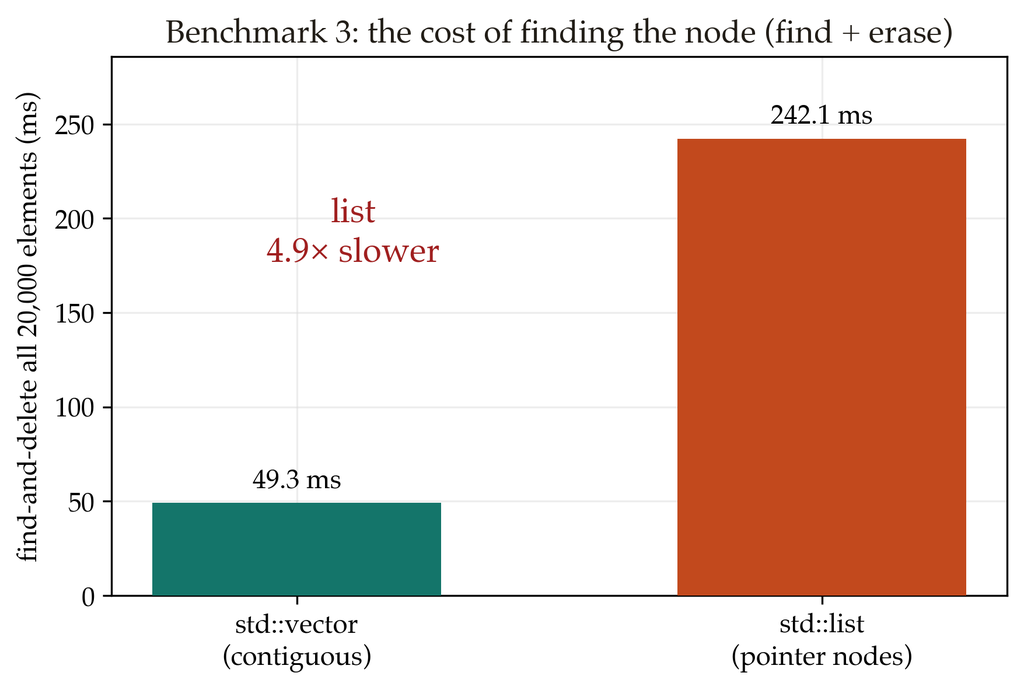

Bar chart. Finding and deleting all 20,000 elements takes about 49 ms with std::vector and about 242 ms with std::list.

The vector took 49.33 ms and the list took 242.14 ms, so the list comes out about five times slower, despite having the supposedly cheaper delete. Finding the node is what really costs you. A list scatters all its nodes across the heap and links them together with pointers, so searching through it means following those pointers all over the place in memory, eating a fresh cache miss at nearly every single node. The vector, meanwhile, just keeps everything packed into one contiguous block, so the search is that same fast scan we already saw back in Experiment 1, and the actual delete is just one bulk `memmove`.

This is basically the result Bjarne Stroustrup is famous for: arrays beat linked lists for most everyday work. And you can really feel your intuition pulling the other way hard on this one. Think about an order book, say, the live list of buy and sell orders in a market. Orders get cancelled constantly, so a linked list looks just about perfect for the job: O(1) to splice one right out. And yet plenty of seriously fast order books keep their orders in contiguous arrays anyway, because walking pointers around to find the order you want to cancel ends up costing way more than all that array shuffling ever does.

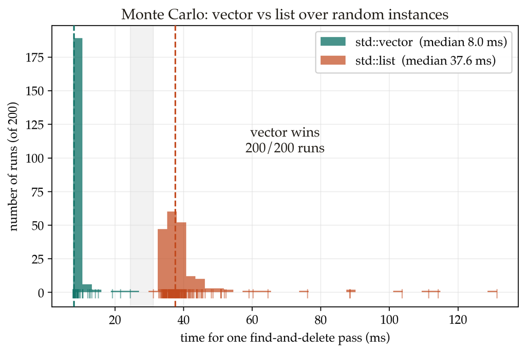

Overlaid histogram of 200 random runs. std::vector times cluster tightly near 8 ms while std::list times spread into a long tail past 100 ms, and vector is faster in every run.

The vector won all 200 runs. But the shapes are the really interesting part here. The vector’s times all bunch up nice and tight near 8 ms, while the list’s spread right out into a long tail that reaches well past 100 ms, basically because how scattered the nodes end up is a bit different from one run to the next. And a tail like that is exactly how a list quietly turns into a random latency spike in production, long after the Big-O up on the whiteboard looked perfectly fine.

## What on earth is happening?

So, a handful of hardware details end up explaining all three of these results.

Big-O is still the right way to think about how cost grows as your inputs get big, and at a large enough N it does always win out in the end. The catch is just that courses tend to treat that ranking as the final answer, when on real hardware it’s honestly a lot closer to the starting point. The real trick is to hold both ideas in your head at the same time: Big-O tells you how things scale, and the cache and the pipeline are the ones that actually decide who’s faster at the size you happen to be running today. And when it really matters, just measure it, with an optimised build, a warm-up, a few runs, and the minimum taken. The two loops at the very top of this page were only a few characters apart, and 70 times apart in speed. Once you start actually measuring, you start finding that gap absolutely everywhere.

## Further reading

- **Bjarne Stroustrup**, who created C++. His list versus vector demonstration is the direct source of Experiment 3, and honestly the fastest way to just see the effect for yourself.
- **Scott Meyers**. His book *Effective C++* is the classic next step in the language, and he’s also got a talk on CPU caches that lines up really nicely with Experiments 1 and 2.
- **Mike Acton**. His CppCon talk on data-oriented design pushes this whole idea much, much further, building entire programs around how the data actually sits in memory.
- **Google Benchmark**, which is the library you’d actually reach for to measure this stuff properly, rather than the little harness I’ve thrown together here in this repo.